# Stat 4750 Final Project

Angelina

2024-12-15

## Data

```r
data <- read.csv("sample-data.csv")
```

## Reaserch Question 1

Do annual GDP and GDP per capita differ between developed and developing countries across continents?

- test for normality and MANOVA

Data:

```r
#organizing data
data1 <- data[,c(5,6,23,24)]

europe_dg <- data1[data1$status == "Developing" & data1$Continent == "Europe", 1:2]
europe_d <- data1[data1$status == "Developed" & data1$Continent == "Europe", 1:2]

south_america_dg <- data1[data1$status == "Developing" & data1$Continent == "South America", 1:2]
south_america_d <- data1[data1$status == "Developed" & data1$Continent == "South America", 1:2]

africa_dg <- data1[data1$status == "Developing" & data1$Continent == "Africa", 1:2]
africa_d <- data1[data1$status == "Developed" & data1$Continent == "Africa", 1:2]

north_america_dg <- data1[data1$status == "Developing" & data1$Continent == "North America", 1:2]
north_america_d <- data1[data1$status == "Developed" & data1$Continent == "North America", 1:2]

asia_dg <- data1[data1$status == "Developing" & data1$Continent == "Asia", 1:2]
asia_d <- data1[data1$status == "Developed" & data1$Continent == "Asia", 1:2]


oceania_dg <- data1[data1$status == "Developing" & data1$Continent == "Oceania", 1:2]
oceania_d <- data1[data1$status == "Developed" & data1$Continent == "Oceania", 1:2]
```

Check Normality:

```r
apply(europe_dg, 2, shapiro.test)
```

```
## $Annual.GDP
##
##  Shapiro-Wilk normality test
##
## data:  newX[, i]
## W = 0.80785, p-value = 3.554e-06
##
##
## $GDP.per.capita
##
##  Shapiro-Wilk normality test
##
## data:  newX[, i]
## W = 0.69478, p-value = 2.236e-08
```

```r
apply(europe_d, 2, shapiro.test)
```

```
## $Annual.GDP
##
##  Shapiro-Wilk normality test
##
## data:  newX[, i]
## W = 0.74138, p-value < 2.2e-16
##
##
## $GDP.per.capita
##
##  Shapiro-Wilk normality test
##
## data:  newX[, i]
## W = 0.96937, p-value = 5.334e-06
```

```r
apply(south_america_dg, 2, shapiro.test)
```

```
## $Annual.GDP
##
##  Shapiro-Wilk normality test
##
## data:  newX[, i]
## W = 0.5381, p-value < 2.2e-16
##
##
## $GDP.per.capita
##
##  Shapiro-Wilk normality test
##
## data:  newX[, i]
## W = 0.92232, p-value = 3.004e-07
```

```r
apply(africa_dg, 2, shapiro.test)
```

```
## $Annual.GDP
##
##  Shapiro-Wilk normality test
##
## data:  newX[, i]
## W = 0.58961, p-value < 2.2e-16
##
##
## $GDP.per.capita
##
##  Shapiro-Wilk normality test
##
## data:  newX[, i]
## W = 0.84238, p-value = 6.815e-16
```

```r
apply(north_america_dg, 2, shapiro.test)
```

```
## $Annual.GDP
##
##  Shapiro-Wilk normality test
##
## data:  newX[, i]
## W = 0.38251, p-value < 2.2e-16
##
##
## $GDP.per.capita
##
##  Shapiro-Wilk normality test
##
## data:  newX[, i]
## W = 0.85536, p-value = 1.812e-11
```

```r
apply(north_america_d, 2, shapiro.test)
```

```
## $Annual.GDP
##
##  Shapiro-Wilk normality test
##
## data:  newX[, i]
## W = 0.78372, p-value = 3.358e-05
##
##
## $GDP.per.capita
##
##  Shapiro-Wilk normality test
##
## data:  newX[, i]
## W = 0.95118, p-value = 0.1818
```

```r
apply(asia_dg, 2, shapiro.test)
```

```
## $Annual.GDP
##
##  Shapiro-Wilk normality test
##
## data:  newX[, i]
## W = 0.73262, p-value < 2.2e-16
##
##
## $GDP.per.capita
##
##  Shapiro-Wilk normality test
##
## data:  newX[, i]
## W = 0.76759, p-value < 2.2e-16
```

```r
apply(asia_d, 2, shapiro.test)
```

```
## $Annual.GDP
##
##  Shapiro-Wilk normality test
##
## data:  newX[, i]
## W = 0.91488, p-value = 0.1609
##
##
## $GDP.per.capita
##
##  Shapiro-Wilk normality test
##
## data:  newX[, i]
## W = 0.9161, p-value = 0.168
```

```r
apply(oceania_d, 2, shapiro.test)
```

```
## $Annual.GDP
##
##  Shapiro-Wilk normality test
##
## data:  newX[, i]
## W = 0.82707, p-value = 0.0002128
##
##
## $GDP.per.capita
##
##  Shapiro-Wilk normality test
##
## data:  newX[, i]
## W = 0.96065, p-value = 0.3219
```

When looking at the normality first, we see if our data deviated from a normal distribution, and most of them did. Since MANOVA is not robust to violations of normality, this issue could potentially affect our results, so it is essential to consider it. However, it is important to state that our sample size is relatively large, and we can still proceed with the analysis according to the central limit theorem.

Manova:

```r
data1$status <- as.factor(data1$status)
data1$Continent <- as.factor(data1$Continent)

fit.lm <- lm(cbind(Annual.GDP, GDP.per.capita)~ status+Continent, data1)

summary(Manova(fit.lm))
```

```
##
## Type II MANOVA Tests:
##
## Sum of squares and products for error:
##                  Annual.GDP GDP.per.capita
## Annual.GDP     2.650845e+15   5.971737e+12
## GDP.per.capita 5.971737e+12   2.898573e+11
##
## ------------------------------------------
##
## Term: status
##
## Sum of squares and products for the hypothesis:
##                  Annual.GDP GDP.per.capita
## Annual.GDP     1.131782e+15   5.792033e+12
## GDP.per.capita 5.792033e+12   2.964143e+10
##
## Multivariate Tests: status
##                  Df test stat approx F num Df den Df     Pr(>F)
## Pillai            1 0.3153302  281.401      2   1222 < 2.22e-16 ***
## Wilks             1 0.6846698  281.401      2   1222 < 2.22e-16 ***
## Hotelling-Lawley  1 0.4605580  281.401      2   1222 < 2.22e-16 ***
## Roy               1 0.4605580  281.401      2   1222 < 2.22e-16 ***
## ---
## Signif. codes:  0 '***' 0.001 '**' 0.01 '*' 0.05 '.' 0.1 ' ' 1
##
## ------------------------------------------
##
## Term: Continent
##
## Sum of squares and products for the hypothesis:
##                   Annual.GDP GDP.per.capita
## Annual.GDP      8.598042e+14  -2.857431e+12
## GDP.per.capita -2.857431e+12   2.708674e+10
##
## Multivariate Tests: Continent
##                  Df test stat  approx F num Df den Df     Pr(>F)
## Pillai            5 0.3494166  51.78006     10   2446 < 2.22e-16 ***
## Wilks             5 0.6642957  55.46135     10   2444 < 2.22e-16 ***
## Hotelling-Lawley  5 0.4847120  59.18333     10   2442 < 2.22e-16 ***
## Roy               5 0.4375343 107.02089      5   1223 < 2.22e-16 ***
## ---
## Signif. codes:  0 '***' 0.001 '**' 0.01 '*' 0.05 '.' 0.1 ' ' 1
```

Looking at our Manova, we see that for status, the Wilks p-value is < 2.22e-16, and for the continent, the Wilks p-value is < 2.22e-16. This suggests that countries categorized as developed versus developing have statistically different annual GDP and GDP per capita. Secondly, it indicates that countries across various continents also contribute to the GDP and GDP per capita differences.

Answering our research question we can see from the Manova that annual GDP and GDP per capita differ between developed and developing countries across continents.

## Research Question 2

What key economic factors can be identified that explain the most variation in CO2 emissions while reducing the complexity of the data?

- ggplot visualization and PCA

Data:

```r
data2 <- data[,c(5, 6, 7, 8, 9, 10, 11, 13, 14, 15, 16, 22)]
```

Correlation Analysis:

```r
cor(data$CO2.Tons.per.capita, data$Annual.GDP)
```

```
## [1] 0.3634231
```

```r
cor(data$CO2.Tons.per.capita, data$GDP.per.capita)
```

```
## [1] 0.6965806
```

```r
cor(data$CO2.Tons.per.capita, data$Debt)
```

```
## [1] 0.3043068
```

```r
cor(data$CO2.Tons.per.capita, data$Debt.Per.Capita)
```

```
## [1] 0.5028634
```

```r
cor(data$CO2.Tons.per.capita, data$Deficit...M...)
```

```
## [1] -0.004269491
```

```r
cor(data$CO2.Tons.per.capita, data$Expenditure..M...)
```

```
## [1] 0.00285722
```

```r
cor(data$CO2.Tons.per.capita, data$Expenditure.Per.Capita)
```

```
## [1] 0.00214431
```

```r
cor(data$CO2.Tons.per.capita, data$Exports)
```

```
## [1] 0.3750233
```

```r
cor(data$CO2.Tons.per.capita, data$Exports...GDP)
```

```
## [1] 0.2163331
```

```r
cor(data$CO2.Tons.per.capita, data$Imports)
```

```
## [1] 0.3981929
```

```r
cor(data$CO2.Tons.per.capita, data$Imports...GDP)
```

```
## [1] 0.05485838
```

When looking at the initial correlation between CO2 emissions per capita and all the economic variables, we mostly have positive correlations except with Deficit…M that has a weak negative correlation. We see strong positive correlations with CO2 emissions and GDP per capita at 0.6965806 and Debt per capita at 0.5028634.

Visualization of the Relationship:

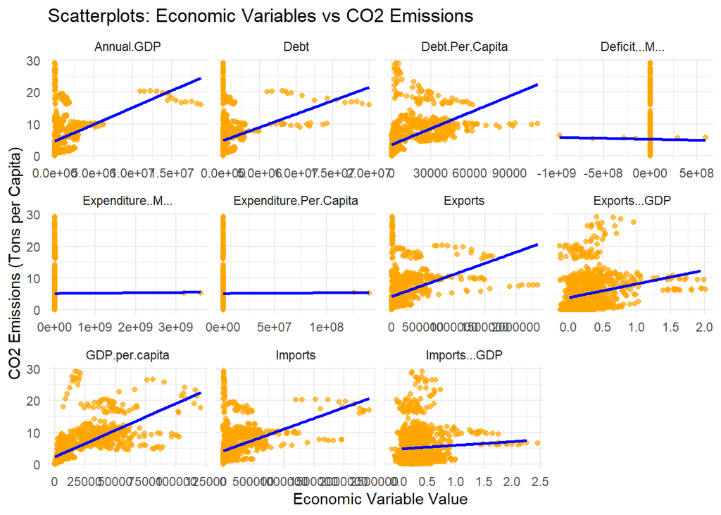

```r
long_data <- data2 |>
  pivot_longer(cols = -CO2.Tons.per.capita, names_to = "Variable", values_to = "Value")

ggplot(long_data, aes(x = Value, y = CO2.Tons.per.capita)) +
  geom_jitter(alpha = 0.7, color = "orange", width = 0.2, height = 0.02) +
  geom_smooth(method = "lm", se = FALSE, color = "blue") +
  facet_wrap(~ Variable, scales = "free_x") +
  labs(title = "Scatterplots: Economic Variables vs CO2 Emissions",
       x = "Economic Variable Value", y = "CO2 Emissions (Tons per Capita)") +
  theme_minimal()
```

Above is a visualization of the correlations we found in the first part. Now we visually see that most of the correlations are positive except Deficit…M and looking at the GPD per capita and Debt per capita, we see that the points are closer along the line indicating a strong strength of correlation.

PCA:

```r
economic_data <- data2 |>
  select(-CO2.Tons.per.capita)

economic_data <- scale(economic_data)

pca <- prcomp(economic_data, scale. = TRUE)

summary(pca)
```

```
## Importance of components:
##                           PC1    PC2    PC3     PC4     PC5     PC6     PC7
## Standard deviation     2.0053 1.4357 1.4014 1.03045 0.99599 0.69069 0.50203
## Proportion of Variance 0.3656 0.1874 0.1785 0.09653 0.09018 0.04337 0.02291
## Cumulative Proportion  0.3656 0.5530 0.7315 0.82805 0.91823 0.96160 0.98451
##                            PC8    PC9    PC10     PC11
## Standard deviation     0.31488 0.2505 0.09182 0.005679
## Proportion of Variance 0.00901 0.0057 0.00077 0.000000
## Cumulative Proportion  0.99353 0.9992 1.00000 1.000000
```

```r
pca$loadings <- pca$rotation%*%diag(pca$sdev)
pca$loadings
```

```
##                                [,1]         [,2]        [,3]         [,4]
## Annual.GDP              0.879296958  0.163710514 -0.12449933 -0.196824359
## GDP.per.capita          0.555527219 -0.242693515  0.20970622  0.695103690
## Debt                    0.890235356  0.162663967 -0.12003511 -0.163342306
## Debt.Per.Capita         0.737499861 -0.127656816  0.12501798  0.535382670
## Deficit...M...          0.008312776 -0.094922447 -0.08165446  0.041975139
## Expenditure..M...      -0.029777655  0.677678623  0.73208069  0.006313788
## Expenditure.Per.Capita -0.033620314  0.676604134  0.73295332  0.008809661
## Exports                 0.856682423 -0.062187212  0.07676780 -0.247788945
## Exports...GDP           0.022568336 -0.706263676  0.65468709 -0.136583695
## Imports                 0.926946005 -0.008895937  0.02810263 -0.289497760
## Imports...GDP          -0.086466066 -0.709951328  0.59950429 -0.246679981
##                                [,5]          [,6]         [,7]         [,8]
## Annual.GDP              0.008381250 -2.717437e-01  0.234151220 -0.045311437
## GDP.per.capita         -0.035832488  1.548971e-01  0.275220844  0.025298505
## Debt                    0.010561194 -3.235951e-01 -0.050992670  0.011036766
## Debt.Per.Capita        -0.016747721 -1.722117e-01 -0.316303952  0.012093884
## Deficit...M...          0.991181980  5.884631e-03  0.002718706 -0.002683492
## Expenditure..M...       0.061981214  8.276538e-05  0.002111741  0.004534708
## Expenditure.Per.Capita  0.061125230  6.179810e-04  0.001902299  0.004673241
## Exports                 0.003723082  4.177622e-01 -0.128581291  0.011310767
## Exports...GDP          -0.005375418 -5.033465e-02 -0.010445321 -0.224450160
## Imports                 0.009593168  2.140254e-01  0.035553729  0.022762722
## Imports...GDP           0.009408250 -1.481106e-01  0.029775965  0.212406847
##                                 [,9]         [,10]         [,11]
## Annual.GDP              0.1176850480 -3.392992e-02  7.861979e-06
## GDP.per.capita         -0.0606605096  4.696986e-04 -5.876040e-06
## Debt                   -0.1796763134  1.006690e-02  5.559764e-06
## Debt.Per.Capita         0.0860282570  9.559622e-04 -2.322423e-06
## Deficit...M...         -0.0005511037 -1.451745e-04  3.004357e-06
## Expenditure..M...       0.0003906741 -3.614134e-05 -4.015255e-03
## Expenditure.Per.Capita  0.0002523941 -1.143841e-04  4.015476e-03
## Exports                -0.0343248548 -5.056621e-02  8.090050e-07
## Exports...GDP          -0.0184047872  4.880308e-03  1.809595e-07
## Imports                 0.0621933680  6.741012e-02  8.342487e-06
## Imports...GDP           0.0124614213 -7.244419e-03 -1.111187e-06
```

The results state:

- PC1 explains 36.56% of the data’s total variance
- I would use four components because PC4 captures 82.81% of the data’s variance
- PC1 is highly associated with Annual.GDP at 0.879296958, Debt at 0.890235356, Exports at 0.856682423, Imports at 0.926946005
- PC2 is positively associated with Expenditure..M at 0.677678623, Expenditure.Per.Capita at 0.676604134 and negatively associated with Exports…GDP at -0.706263676, Imports…GDP at -0.709951328
- We could continue to show which variables are highly associated with CO2 emissions but for now, we will stick with these and continue to look above.

Looking at the PCA regarding our research questions, we see which economic variables are most related to CO2 emissions. PC1 captures GDP, debt, exports, and imports which logically are all typically associated with higher CO2 emissions. The component likely reflects the general economic activity and how it correlates with CO2 emission. PC2 reflects newer economic activities like expenditure. Again, this can be another cause/correlation to environmental outcomes. Overall, PC1 explains the largest population of variance, around 36.56% and might be the most relevant to CO2 emission, especially given the variables it outputted.

## Research Question 3

Can clustering methods group countries meaningfully based on their social indicators?

- clustering

Data:

```r
data3 <- data[,c(17, 18, 19, 20, 21, 24)]

data3$status <-ifelse(data3$status=="Developing",1,0)

data3 <- na.omit(data3)

data3 <- scale(data3)
```

K-Means Clustering:

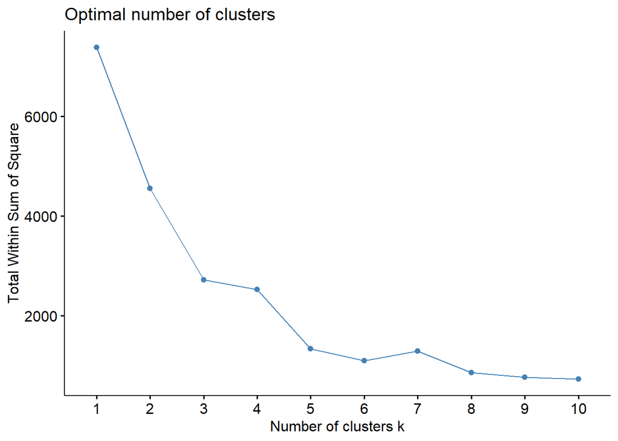

```r
fviz_nbclust(data3, kmeans, method = "wss")
```

```r
set.seed(1)

km <- kmeans(data3, centers = 4)

split(data$Country, km$cluster)
```

```
## $`1`
##   [1] "Albania"             "Albania"             "Albania"
##   [4] "Albania"             "Albania"             "Albania"
##   [7] "Albania"             "Albania"             "Albania"
##  [10] "Albania"             "Albania"             "Albania"
##  [13] "Albania"             "Albania"             "Albania"
##  [16] "Argentina"           "Argentina"           "Argentina"
##  [19] "Argentina"           "Argentina"           "Argentina"
##  [22] "Argentina"           "Argentina"           "Argentina"
##  [25] "Argentina"           "Argentina"           "Argentina"
##  [28] "Argentina"           "Argentina"           "Argentina"
##  [31] "Bolivia"             "Bolivia"             "Bolivia"
##  [34] "Bolivia"             "Bolivia"             "Bolivia"
##  [37] "Bolivia"             "Bolivia"             "Bolivia"
##  [40] "Bolivia"             "Bolivia"             "Botswana"
```

[output cut: 335 more lines]

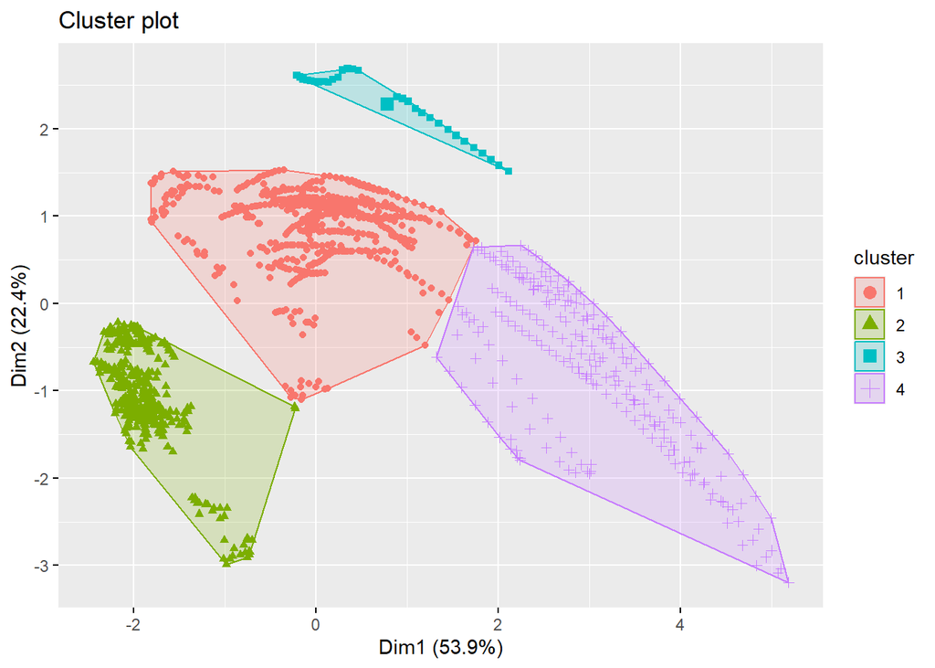

```r
fviz_cluster(km, data = data3, geom = "point")
```

Looking at the clusters and the visualization we see it created 4 clusters done by the wss method. I would have to do further research about the countries to find a good reason why the groups are put together. However, we do see that most clusters represent the entire 15 variables of the country, showing consistency among that country with respect to social indicators. However, there are some countries out of their 15 variables that are grouped in other clusters.

So, to answer the research question of can clustering methods group countries meaningfully based on their social indicators, I would have to do further factual research about the country to say yes or no. I see a pattern showing some meaningfulness of the clusters but some outliers in these groups. So overall, the clustering results show potential meaningful groupings of countries based on their social indicators, but further investigation is needed to confirm whether these groupings align with known factors.

## Research Question 4

How well can developed and developing statuses be classified using economic and environmental variables?

- two classification methods

Data:

```r
data4 <- data[ ,c(5, 6, 7, 8, 9, 10, 11, 13, 14, 15, 16, 22, 24)]

data4$status<-ifelse(data4$status=="Developing",1,0)
```

Logistic Regression:

```r
logr<-glm(status ~ Annual.GDP+GDP.per.capita+Debt+Debt.Per.Capita+Deficit...M...+Expenditure..M...+Expenditure.Per.Capita+Exports+Exports...GDP+Imports+Imports...GDP+CO2.Tons.per.capita,
                   family=binomial, data=data4)

summary(logr)
```

```
##
## Call:
## glm(formula = status ~ Annual.GDP + GDP.per.capita + Debt + Debt.Per.Capita +
##     Deficit...M... + Expenditure..M... + Expenditure.Per.Capita +
##     Exports + Exports...GDP + Imports + Imports...GDP + CO2.Tons.per.capita,
##     family = binomial, data = data4)
##
## Coefficients:
##                          Estimate Std. Error z value Pr(>|z|)
## (Intercept)             2.556e+00  2.906e-01   8.796  < 2e-16 ***
## Annual.GDP             -1.561e-06  8.157e-07  -1.914  0.05565 .
## GDP.per.capita          3.841e-05  1.848e-05   2.078  0.03772 *
## Debt                   -1.715e-07  7.575e-07  -0.226  0.82085
## Debt.Per.Capita        -1.508e-04  1.866e-05  -8.083 6.30e-16 ***
## Deficit...M...         -6.361e-10  2.912e-09  -0.218  0.82706
## Expenditure..M...       4.261e-06  1.541e-06   2.766  0.00568 **
## Expenditure.Per.Capita -1.074e-04  3.884e-05  -2.765  0.00569 **
## Exports                 3.962e-06  2.816e-06   1.407  0.15937
## Exports...GDP           6.564e-01  1.134e+00   0.579  0.56265
## Imports                -6.036e-06  3.518e-06  -1.716  0.08618 .
## Imports...GDP           2.284e+00  1.279e+00   1.786  0.07402 .
## CO2.Tons.per.capita    -1.093e-01  2.276e-02  -4.802 1.57e-06 ***
## ---
## Signif. codes:  0 '***' 0.001 '**' 0.01 '*' 0.05 '.' 0.1 ' ' 1
##
## (Dispersion parameter for binomial family taken to be 1)
##
##     Null deviance: 1512.75  on 1229  degrees of freedom
## Residual deviance:  657.59  on 1217  degrees of freedom
## AIC: 683.59
##
## Number of Fisher Scoring iterations: 9
```

Logistic Regression Results:

- Intercept: p-value < 2e-16
- GDP per capita, Debt.Per.Capita, Expenditure..M…, Expenditure.Per.Capita, and CO2.Tons.per.capita are significant.
- Other variables are not statistically significant
- Null deviance: 1512.75
- Residual deviance: 657.59
- AIC: 683.59

Random Forrest:

```r
randomf <- randomForest(status ~ Annual.GDP+GDP.per.capita+Debt+Debt.Per.Capita+Expenditure..M...+Expenditure.Per.Capita+Exports+Exports...GDP+Imports+Imports...GDP+CO2.Tons.per.capita, data = data4, importance = TRUE)
print(randomf)
```

```
##
## Call:
##  randomForest(formula = status ~ Annual.GDP + GDP.per.capita +      Debt + Debt.Per.Capita + Expenditure..M... + Expenditure.Per.Capita +      Exports + Exports...GDP + Imports + Imports...GDP + CO2.Tons.per.capita,      data = data4, importance = TRUE)
##                Type of random forest: regression
##                      Number of trees: 500
## No. of variables tried at each split: 3
##
##           Mean of squared residuals: 0.009657037
##                     % Var explained: 95.44
```

Random Forest Results: